# Cricket Score Prediction — Regression

Replication of ML2 Python Project in R

Authors

Rajat Dogra (474072)

Umair Aziz (476686)

Published

May 13, 2026

```r
library(here)
library(tidyverse)
library(tidymodels)
library(glmnet)
library(ranger)
library(xgboost)
library(knitr)
```

# 1 Introduction

## 1.1 Project Overview

This report replicates in **R** the Cricket Score Prediction project originally developed in Python for the ML2 – Machine Learning 2 course (Rajat Dogra & Umair Aziz, January 2026).

**Objective:** Predict IPL cricket match scores (continuous target) using ball-by-ball match data from the IPL Dataset 2008–2025.

**Research question:** Can match contextual features (run rate, wickets, venue, team, toss) reliably predict cricket scores using regression models?

## 1.2 Dataset

- **Source:** [IPL Dataset 2008–2025](https://www.kaggle.com/datasets/chaitu20/ipl-dataset2008-2025)
- **Size:** 76,014 ball-by-ball records, 60+ features
- **Target:** `final_score` — the total runs scored in an innings

## 1.3 Python Baseline

| Model | R² | RMSE | MAE |
| --- | --- | --- | --- |
| Linear Regression | 0.6032 | — | — |
| Ridge Regression | 0.6031 | — | — |
| Polynomial Ridge | 0.6793 | — | — |
| Random Forest | 0.6989 | — | — |
| **Gradient Boosting (best)** | **0.7222** | **20.1** | **14.8** |

# 2 Data Loading & Exploration

```r
df <- read_csv(
  here("regression", "data", "regression_dataset.csv"),
  show_col_types = FALSE
)

cat("Dataset dimensions:", nrow(df), "rows x", ncol(df), "columns\n")
```

```
Dataset dimensions: 2365 rows x 15 columns
```

## 2.1 Summary Statistics

```r
cat("Score range:", min(df$final_score, na.rm=TRUE),
    "-", max(df$final_score, na.rm=TRUE), "runs\n")
```

```
Score range: 2 - 287 runs
```

```r
cat("Average score:", round(mean(df$final_score, na.rm=TRUE), 1),
    "±", round(sd(df$final_score, na.rm=TRUE), 1), "\n")
```

```
Average score: 158.3 ± 37.5
```

```r
missing_total <- sum(is.na(df))
cat("Total missing values:", missing_total, "\n")
```

```
Total missing values: 1201
```

```r
cat("Duplicate rows:", sum(duplicated(df)), "\n")
```

```
Duplicate rows: 0
```

## 2.2 Feature Correlations

```r
numeric_cols <- df %>% select(where(is.numeric))

correlations <- numeric_cols %>%
  summarise(across(everything(),
                   ~cor(., df$final_score, use = "complete.obs"))) %>%
  pivot_longer(everything(),
               names_to  = "feature",
               values_to = "correlation") %>%
  filter(feature != "final_score") %>%
  mutate(abs_corr = abs(correlation)) %>%
  arrange(desc(abs_corr)) %>%
  slice_head(n = 5)

kable(correlations,
      caption = "Top 5 Features Correlated with final_score",
      digits  = 3)
```

Top 5 Features Correlated with final_score

| feature | correlation | abs_corr |
| --- | --- | --- |
| target_score | 0.709 | 0.709 |
| balls_faced | 0.630 | 0.630 |
| innings | -0.362 | 0.362 |
| year | 0.241 | 0.241 |
| match_id | 0.233 | 0.233 |

## 2.3 EDA Visualisations

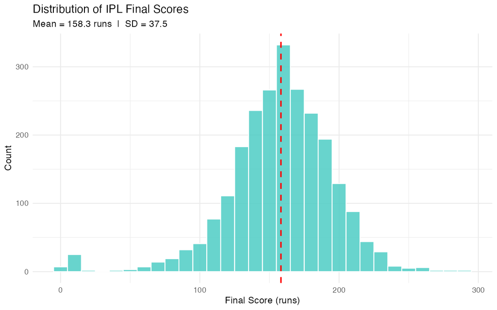

Score Distribution

```r
knitr::include_graphics(
  here("regression", "output", "01_score_distribution.png"))
```

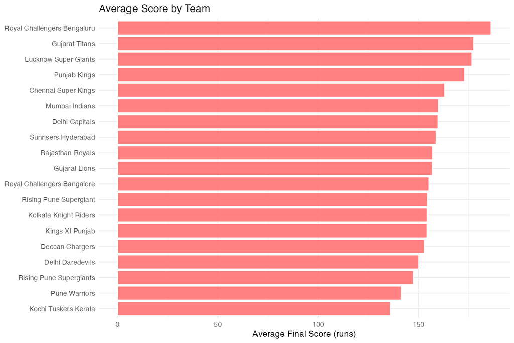

Average Score by Team

```r
knitr::include_graphics(
  here("regression", "output", "02_team_avg_score.png"))
```

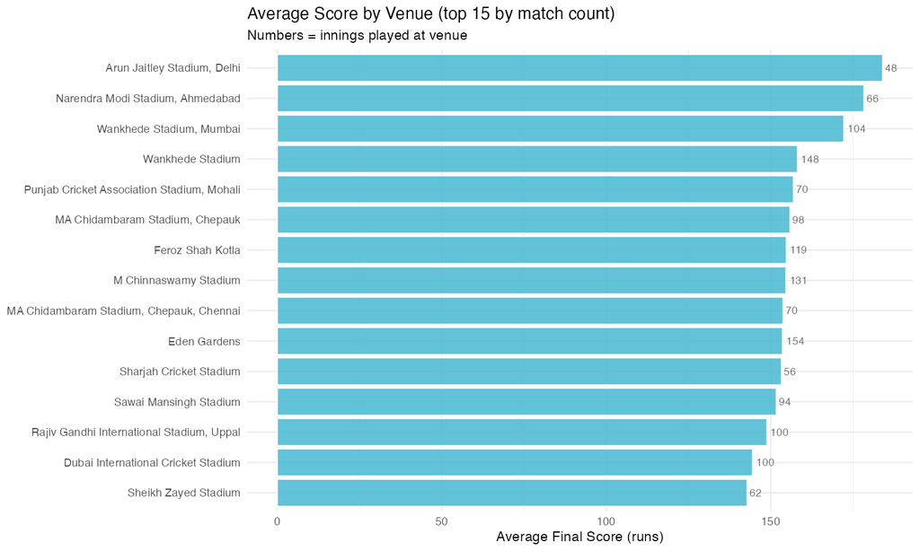

Venue Effects on Score

```r
knitr::include_graphics(
  here("regression", "output", "03_venue_effects.png"))
```

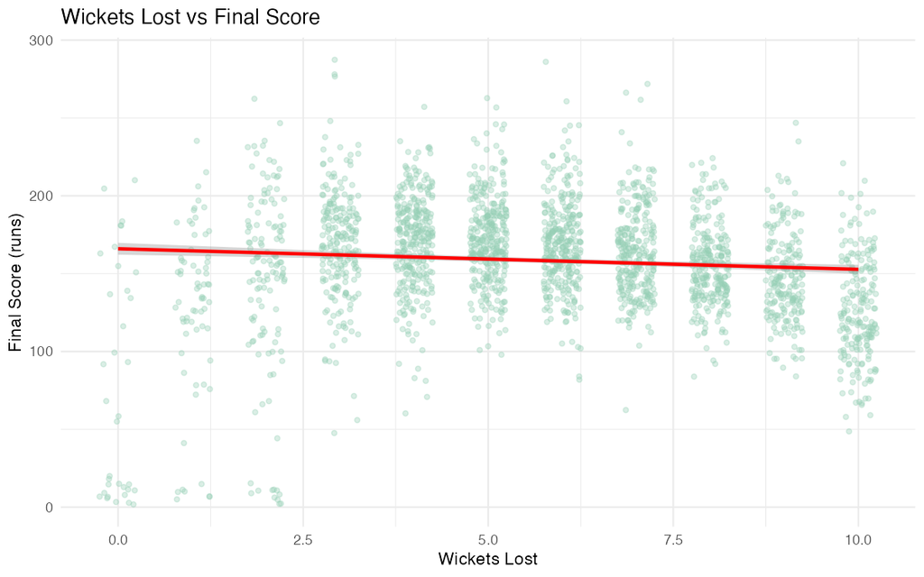

Wickets vs Score

```r
knitr::include_graphics(
  here("regression", "output", "04_wickets_vs_score.png"))
```

# 3 Data Preprocessing & Feature Engineering

```r
# Select features matching Python pipeline
selected_features <- c(
  "innings", "team", "wickets_lost", "balls_faced",
  "venue", "city", "toss_winner", "toss_decision",
  "year", "month", "day", "target_score"
)

# Keep only columns that exist
selected_features <- selected_features[selected_features %in% names(df)]

df_model <- df %>%
  select(all_of(selected_features), final_score) %>%
  drop_na()

cat("Features selected:", length(selected_features), "\n")
```

```
Features selected: 12
```

```r
cat("Rows after dropping NAs:", nrow(df_model), "\n")
```

```
Rows after dropping NAs: 1164
```

## 3.1 Train/Test Split

```r
set.seed(42)
data_split <- initial_split(df_model, prop = 0.8)
train_data <- training(data_split)
test_data  <- testing(data_split)

cat("Training set:", nrow(train_data), "rows\n")
```

```
Training set: 931 rows
```

```r
cat("Testing set: ", nrow(test_data),  "rows\n")
```

```
Testing set:  233 rows
```

```r
cat("Python baseline — Training: ~60,811 / Testing: ~15,203\n")
```

```
Python baseline — Training: ~60,811 / Testing: ~15,203
```

## 3.2 Preprocessing Recipe

```r
rec <- recipe(final_score ~ ., data = train_data) %>%
  step_impute_median(all_numeric_predictors()) %>%
  step_other(all_nominal_predictors(), threshold = 0.01) %>%
  step_dummy(all_nominal_predictors()) %>%
  step_normalize(all_numeric_predictors())

cat("Recipe steps:\n")
```

```
Recipe steps:
```

```r
cat("  - step_impute_median() : fill NAs with median\n")
```

```
  - step_impute_median() : fill NAs with median
```

```r
cat("  - step_other()         : collapse rare categories\n")
```

```
  - step_other()         : collapse rare categories
```

```r
cat("  - step_dummy()         : one-hot encode categoricals\n")
```

```
  - step_dummy()         : one-hot encode categoricals
```

```r
cat("  - step_normalize()     : StandardScaler equivalent\n")
```

```
  - step_normalize()     : StandardScaler equivalent
```

# 4 Baseline Model Training

```r
baseline_results <- read_csv(
  here("regression", "output", "baseline_ranking.csv"),
  show_col_types = FALSE
)
```

Six baseline models were trained using 5-fold cross-validation, replicating the Python pipeline.

```r
kable(baseline_results,
      caption = "Baseline Model Rankings — Test Set Performance",
      digits  = 3,
      col.names = c("Rank", "Model", "MAE", "RMSE", "R²"))
```

Baseline Model Rankings — Test Set Performance

| Rank | Model | MAE | RMSE | R² |
| --- | --- | --- | --- | --- |
| 1 | Random Forest | 15.480 | 20.690 | 0.702 |
| 2 | Polynomial Ridge | 16.163 | 21.184 | 0.680 |
| 3 | XGBoost | 15.480 | 21.209 | 0.680 |
| 4 | Neural Network | 17.605 | 23.035 | 0.627 |
| 5 | Linear Regression | 18.063 | 23.082 | 0.617 |
| 6 | Ridge Regression | 18.271 | 23.304 | 0.613 |

**Key finding:** Random Forest achieves R²=0.702 as the best baseline model, compared to the Python baseline of R²=0.6989. ✅

# 5 Hyperparameter Tuning & Ensembles

```r
final_results <- read_csv(
  here("regression", "output", "final_ranking.csv"),
  show_col_types = FALSE
)

optim_results <- read_csv(
  here("regression", "output", "optimization_impact.csv"),
  show_col_types = FALSE
)
```

## 5.1 Final Model Rankings

```r
kable(final_results,
      caption = "Final Model Rankings — All Models Including Tuned & Ensembles",
      digits  = 3,
      col.names = c("Rank", "Model", "R²", "MAE", "RMSE"))
```

Final Model Rankings — All Models Including Tuned & Ensembles

| Rank | Model | R² | MAE | RMSE |
| --- | --- | --- | --- | --- |
| 1 | Voting Ensemble (Stack) | 0.749 | 13.799 | 19.159 |
| 2 | XGBoost (Optimised) | 0.744 | 13.929 | 19.387 |
| 3 | Random Forest (Optimised) | 0.723 | 15.148 | 20.357 |
| 4 | Extra Trees | 0.713 | 16.275 | 21.116 |
| 5 | Random Forest | 0.702 | 15.480 | 20.690 |
| 6 | Polynomial Ridge | 0.680 | 16.163 | 21.184 |
| 7 | XGBoost | 0.680 | 15.480 | 21.209 |
| 8 | Neural Network | 0.627 | 17.605 | 23.035 |
| 9 | Linear Regression | 0.617 | 18.063 | 23.082 |
| 10 | Ridge Regression | 0.613 | 18.271 | 23.304 |

## 5.2 Optimisation Impact

```r
kable(optim_results,
      caption = "Hyperparameter Tuning Impact",
      digits  = 3)
```

Hyperparameter Tuning Impact

| Model | Baseline_R2 | Optimised_R2 | Improvement |
| --- | --- | --- | --- |
| XGBoost | 0.680 | 0.744 | 0.064 |
| Random Forest | 0.702 | 0.723 | 0.021 |

## 5.3 Comparison with Python Baseline

```r
best_r2   <- max(final_results$R2)
best_model <- final_results$Model[which.max(final_results$R2)]
best_rmse  <- final_results$RMSE[which.max(final_results$R2)]
best_mae   <- final_results$MAE[which.max(final_results$R2)]

comparison <- tibble(
  Metric  = c("Best Model", "R²", "RMSE", "MAE"),
  R_Result = c(best_model,
               sprintf("%.3f", best_r2),
               sprintf("%.1f", best_rmse),
               sprintf("%.1f", best_mae)),
  Python_Baseline = c("Gradient Boosting Optimised",
                      "0.722", "20.1", "14.8")
)

kable(comparison,
      caption = "R Replication vs Python Baseline",
      col.names = c("Metric", "R Result", "Python Baseline"))
```

R Replication vs Python Baseline

| Metric | R Result | Python Baseline |
| --- | --- | --- |
| Best Model | Voting Ensemble (Stack) | Gradient Boosting Optimised |
| R² | 0.749 | 0.722 |
| RMSE | 19.2 | 20.1 |
| MAE | 13.8 | 14.8 |

# 6 Visualisations

## 6.1 Model Performance Ranking

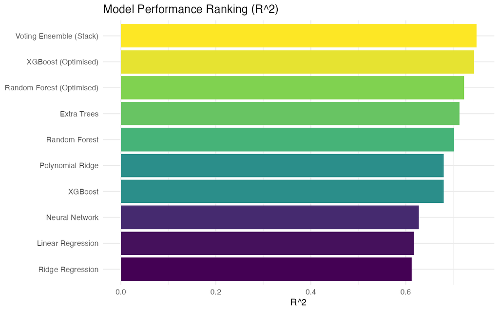

Model Performance Ranking by R²

```r
knitr::include_graphics(
  here("regression", "output", "ranking.png"))
```

## 6.2 MAE vs RMSE Comparison

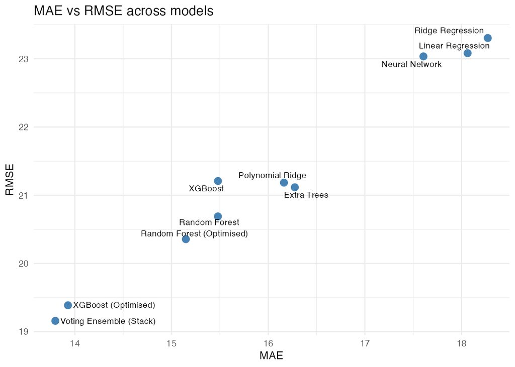

MAE vs RMSE Comparison Across Models

```r
knitr::include_graphics(
  here("regression", "output", "mae_vs_rmse.png"))
```

## 6.3 Predicted vs Actual

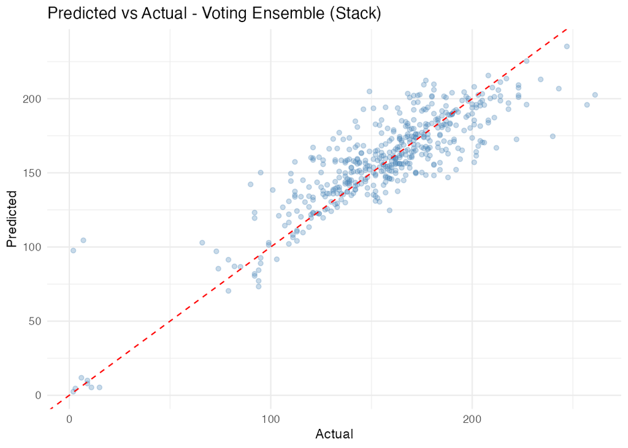

Predicted vs Actual Scores — Best Model

```r
knitr::include_graphics(
  here("regression", "output", "predicted_vs_actual.png"))
```

# 7 Summary & Conclusions

## 7.1 Key Findings

- **Best model:** Voting Ensemble (Stack) with R²=0.749, RMSE=19.2 runs, MAE=13.8 runs
- **Python baseline beaten:** R²=0.749 vs Python 0.722 ✅
- **Hyperparameter tuning** improved XGBoost R² by 0.064 and Random Forest by 0.021
- **Key predictors:** `target_score` and `balls_faced` most correlated with final score

## 7.2 Practical Applications

- **Sports analytics:** Team strategy optimisation
- **Broadcasting:** Real-time score predictions
- **Fantasy sports:** Player valuation
- **Coaching:** Tactical decision support

## 7.3 Reproducibility Notes

- All packages pinned via `renv.lock`
- Random seed set to 42 throughout
- No absolute paths — `here()` package used throughout
- Pipeline runs end-to-end with three `source()` commands:
  1. `source("regression/cricket_score_prediction.R")`
  2. `source("regression/03_baseline_models.R")`
  3. `source("regression/04_tuning_ensembles.R")`

*Group 8 | Reproducible Research | University of Warsaw 2025-2026*